# factorial

alesteba

2023-12-29

The following data set contains essential values from analyzed trajectories. Along this notebook we compute the factor analysis and plot the variable relationships to the factors to get a better understanding of the data.

```r
trjs_data <- read.csv("./trjs_data.csv", header=TRUE, stringsAsFactors=FALSE)

trjs_data
```

```
##    speed_mean  accel_mean    sinuosity         Emax direc_change min_deltaS
## 1   101.29690   6.1152534 0.0153490414     373.9604   73.1767136          2
## 2    98.24034   5.5651497 0.0132566119     453.1446   68.5115989          1
## 3   101.40348  52.3870428 0.0079908201    1338.2549   38.9010936         13
## 4    98.39967 -19.1770595 0.0169052534     289.1189   77.6572089          2
## 5   101.17234   7.4836899 0.0108414923     662.4683   52.5853964          7
## 6   102.23196   6.1805383 0.0031594004    8891.4397   15.5836367          6
## 7   101.79218   9.0859072 0.0131674759     457.0960   64.0448830          2
## 8   100.11877  24.5745219 0.0045109804    3948.0134   20.8092379          5
## 9   101.25749 -18.9634575 0.0131791897     480.4287   62.5678126          2
## 10  100.91002 -24.8072337 0.0006142380  237124.3271    2.7426132         13
## 11   98.14117 -18.3740059 0.0190375547     242.0985   90.6284469          1
## 12  100.23277 -16.3388188 0.0093592806     963.3875   45.9573197         13
## 13   97.93189  -3.6164629 0.0185180389     245.8159   95.9196978          1
## 14  102.92504  -0.2942570 0.0067756288    1652.5516   33.3404049         11
```

[output cut: 87 more lines]

$$𝑥 − 𝜇 = 𝐿𝐹 + 𝜀$$
The coefficient $l_{i,j}$ is the charge of the $i-th$ variable in the $j$ th factor, therefore, $L$ is the loading matrix.

```r
X <- trjs_data

p <- ncol(X)

R <- cor(X)

R
```

```
##               speed_mean  accel_mean  sinuosity        Emax direc_change
## speed_mean    1.00000000  0.04707963  0.1695415 -0.26639332    0.1539581
## accel_mean    0.04707963  1.00000000 -0.1268009 -0.02978213   -0.1338623
## sinuosity     0.16954154 -0.12680087  1.0000000 -0.27291403    0.9971958
## Emax         -0.26639332 -0.02978213 -0.2729140  1.00000000   -0.2707085
## direc_change  0.15395814 -0.13386235  0.9971958 -0.27070852    1.0000000
## min_deltaS    0.14223203 -0.02247919 -0.4550168  0.25768976   -0.4530234
## min_C        -0.28672643 -0.18781813  0.6333184 -0.04478857    0.6686601
##               min_deltaS       min_C
## speed_mean    0.14223203 -0.28672643
## accel_mean   -0.02247919 -0.18781813
## sinuosity    -0.45501679  0.63331835
## Emax          0.25768976 -0.04478857
## direc_change -0.45302344  0.66866013
## min_deltaS    1.00000000 -0.41537537
## min_C        -0.41537537  1.00000000
```

The eigen() function computes the eigenvalues and eigenvectors simultaneously

```r
Reig<- eigen(R)

Reig
```

```
## eigen() decomposition
## $values
## [1] 2.976694253 1.406624094 1.033837257 0.799999673 0.515804333 0.265441231
## [7] 0.001599158
##
## $vectors
##             [,1]        [,2]         [,3]        [,4]        [,5]        [,6]
## [1,] -0.02351279  0.72464990 -0.301065791 -0.25835124  0.33731628  0.45069526
## [2,]  0.10724810  0.22876820  0.810886618 -0.49264173 -0.18604566  0.03628979
## [3,] -0.54609735  0.09899645 -0.097521336 -0.24815327 -0.03420095 -0.37854411
## [4,]  0.21107279 -0.51348500 -0.174779655 -0.66031997  0.47433869 -0.01359013
## [5,] -0.55118330  0.07988883 -0.099871802 -0.24587382 -0.06434601 -0.30720055
## [6,]  0.37140948  0.09032385 -0.449199525 -0.35000812 -0.72261086 -0.08583899
## [7,] -0.45102431 -0.36679675 -0.003058445 -0.09998319 -0.31485072  0.74184634
##               [,7]
## [1,] -0.0059334912
## [2,] -0.0001783465
## [3,] -0.6902329920
## [4,]  0.0054002777
## [5,]  0.7217159033
## [6,] -0.0087129569
## [7,] -0.0506384729
```

```r
Reig$vectors %*% diag(Reig$values) %*% t(Reig$vectors)
```

```
##             [,1]        [,2]       [,3]        [,4]       [,5]        [,6]
## [1,]  1.00000000  0.04707963  0.1695415 -0.26639332  0.1539581  0.14223203
## [2,]  0.04707963  1.00000000 -0.1268009 -0.02978213 -0.1338623 -0.02247919
## [3,]  0.16954154 -0.12680087  1.0000000 -0.27291403  0.9971958 -0.45501679
## [4,] -0.26639332 -0.02978213 -0.2729140  1.00000000 -0.2707085  0.25768976
## [5,]  0.15395814 -0.13386235  0.9971958 -0.27070852  1.0000000 -0.45302344
## [6,]  0.14223203 -0.02247919 -0.4550168  0.25768976 -0.4530234  1.00000000
## [7,] -0.28672643 -0.18781813  0.6333184 -0.04478857  0.6686601 -0.41537537
##             [,7]
## [1,] -0.28672643
## [2,] -0.18781813
## [3,]  0.63331835
## [4,] -0.04478857
## [5,]  0.66866013
## [6,] -0.41537537
## [7,]  1.00000000
```

Cumulative percentages of variance.

```r
100*cumsum(Reig$values)/p
```

```
## [1]  42.52420  62.61883  77.38794  88.81650  96.18514  99.97715 100.00000
```

We choose the number of factors and compute the estimation of the loading matrix. (in this case m = 2)

$$L = ( \sqrt{\lambda_1} U_1\quad \vdots
\cdots \vdots \quad \sqrt{\lambda_m} U_m )$$

```r
m <- 2

sum(Reig$values[(m + 1):p])
```

```
## [1] 2.616682
```

```r
L <- (rep(1, p) %*% t(sqrt(Reig$values[1:m]))) * Reig$vectors[, 1:m]
```

Communalities:

$$h_i^2 = L_{i,1}^2 + \cdots + L_{i,m}^2$$

```r
h2 <- rowSums(L^2)

h2
```

```
## [1] 0.7402886 0.1078539 0.9015020 0.5034970 0.9133061 0.4220959 0.7947749
```

Uniqueness or specific variance:

```r
psi <- 1 - h2

psi
```

```
## [1] 0.25971142 0.89214608 0.09849802 0.49650301 0.08669388 0.57790411 0.20522513
```

```r
Rscr<- L%*%t(L) + diag(psi)

Rscr
```

```
##             [,1]       [,2]       [,3]       [,4]       [,5]        [,6]
## [1,]  1.00000000  0.2256794  0.1391296 -0.5381735  0.1200090  0.06607291
## [2,]  0.22567938  1.0000000 -0.1424826 -0.0978509 -0.1502549  0.14763593
## [3,]  0.13912964 -0.1424826  1.0000000 -0.4146157  0.9071088 -0.59117252
## [4,] -0.53817347 -0.0978509 -0.4146157  1.0000000 -0.4040101  0.16811712
## [5,]  0.12000903 -0.1502549  0.9071088 -0.4040101  1.0000000 -0.59922306
## [6,]  0.06607291  0.1476359 -0.5911725  0.1681171 -0.5992231  1.00000000
## [7,] -0.34231223 -0.2620190  0.6820925 -0.0184481  0.6987792 -0.54524221
##            [,7]
## [1,] -0.3423122
## [2,] -0.2620190
## [3,]  0.6820925
## [4,] -0.0184481
## [5,]  0.6987792
## [6,] -0.5452422
## [7,]  1.0000000
```

```r
D <- R - Rscr

sum(D^2)
```

```
## [1] 0.5421366
```

Graphic representation of the loadings in the factor space.

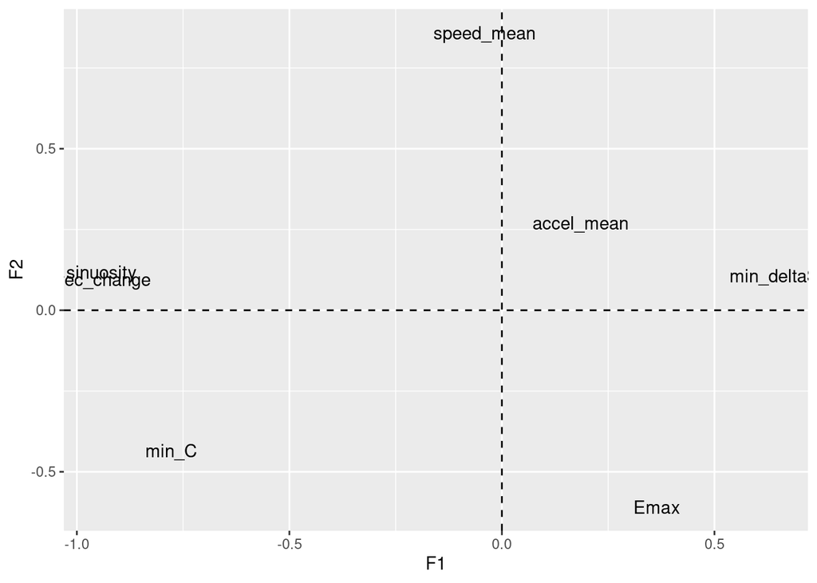

```r
L <- as.data.frame(L)
rownames(L) <- colnames(X)
colnames(L) <- c("F1", "F2")

library(ggplot2)
ggplot(L, aes(x = F1, y = F2, label = rownames(L))) +
geom_hline(yintercept = 0, lty = 2) +
geom_vline(xintercept = 0, lty = 2) +
geom_text()
```

Factor rotation: varimax method

$$𝑥 − \mu = LF + \epsilon = LTT′ 𝐹𝐹 +
\epsilon = (LT) (T′𝐹) + \epsilon = L^*F^*+ \epsilon$$

```r
vmax_L <- varimax(as.matrix(L))
```

Graphic representation of the loadings in the space of the rotated factors.

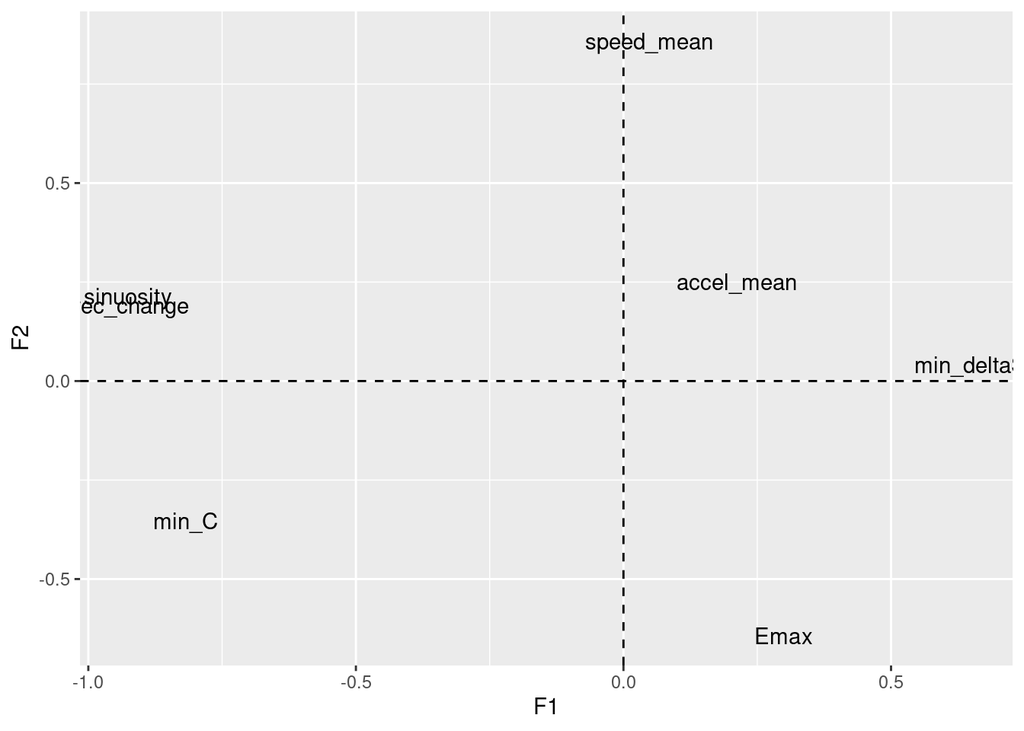

```r
Lstar <- as.data.frame(vmax_L$loadings[, 1:m])

rownames(Lstar) <- colnames(X)
colnames(Lstar) <- c("F1", "F2")

ggplot(Lstar, aes(x = F1, y = F2, label = rownames(Lstar))) +
geom_hline(yintercept = 0, lty = 2) +
geom_vline(xintercept = 0, lty = 2) +
geom_text()
```

The following library uses the previous method and provides functions to easily display and plot the principal components. Within this example we factor into two components and show the relationship between the calculated factors and the data set variables.

```r
library(psych)

trjs_af <- principal(X, nfactors = 2, rotate = "none")

trjs_af
```

```
## Principal Components Analysis
## Call: principal(r = X, nfactors = 2, rotate = "none")
## Standardized loadings (pattern matrix) based upon correlation matrix
##                PC1   PC2   h2    u2 com
## speed_mean    0.04  0.86 0.74 0.260 1.0
## accel_mean   -0.19  0.27 0.11 0.892 1.8
## sinuosity     0.94  0.12 0.90 0.098 1.0
## Emax         -0.36 -0.61 0.50 0.497 1.6
## direc_change  0.95  0.09 0.91 0.087 1.0
## min_deltaS   -0.64  0.11 0.42 0.578 1.1
## min_C         0.78 -0.44 0.79 0.205 1.6
##
##                        PC1  PC2
## SS loadings           2.98 1.41
## Proportion Var        0.43 0.20
## Cumulative Var        0.43 0.63
## Proportion Explained  0.68 0.32
## Cumulative Proportion 0.68 1.00
##
## Mean item complexity =  1.3
## Test of the hypothesis that 2 components are sufficient.
##
## The root mean square of the residuals (RMSR) is  0.11
##  with the empirical chi square  27.11  with prob <  0.00068
##
## Fit based upon off diagonal values = 0.91
```

```r
trjs_af$values
```

```
## [1] 2.976694253 1.406624094 1.033837257 0.799999673 0.515804333 0.265441231
## [7] 0.001599158
```

```r
trjs_af$loadings
```

```
##
## Loadings:
##              PC1    PC2
## speed_mean           0.859
## accel_mean   -0.185  0.271
## sinuosity     0.942  0.117
## Emax         -0.364 -0.609
## direc_change  0.951
## min_deltaS   -0.641  0.107
## min_C         0.778 -0.435
##
##                  PC1   PC2
## SS loadings    2.977 1.407
## Proportion Var 0.425 0.201
## Cumulative Var 0.425 0.626
```

```r
trjs_af$communality
```

```
##   speed_mean   accel_mean    sinuosity         Emax direc_change   min_deltaS
##    0.7402886    0.1078539    0.9015020    0.5034970    0.9133061    0.4220959
##        min_C
##    0.7947749
```

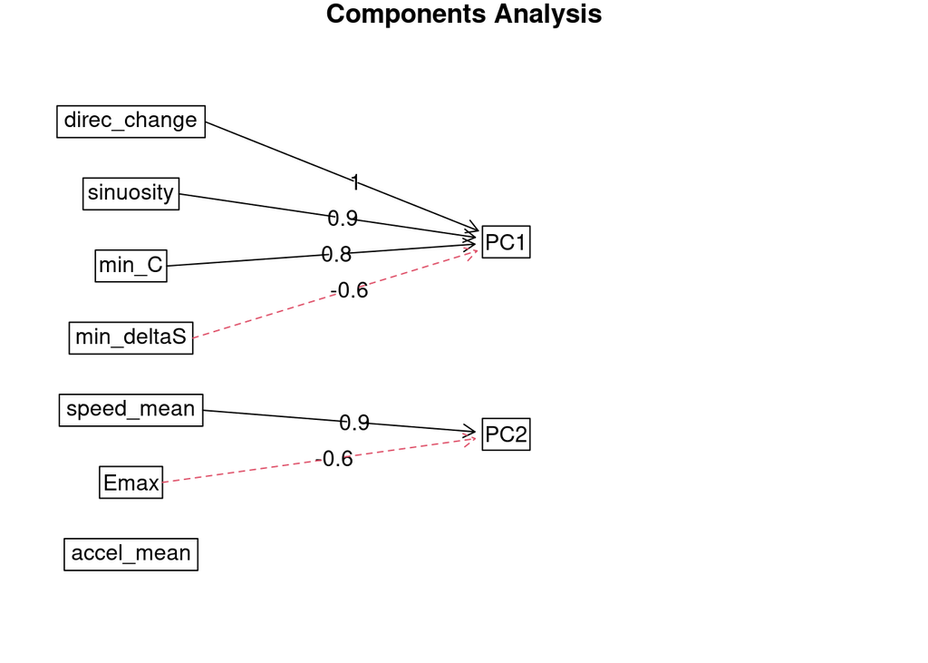

```r
fa.diagram(trjs_af)
```